```r
vectorA <- c(1,2,3,4,5)

matrixA <- matrix(0,nrow = 5, ncol =5)

for (i in 1:5)
  for (j in 1:5)
  {
    matrixA[i,j] <- abs (vectorA[i] - vectorA[j])
  }

matrixA
```

```
##      [,1] [,2] [,3] [,4] [,5]
## [1,]    0    1    2    3    4
## [2,]    1    0    1    2    3
## [3,]    2    1    0    1    2
## [4,]    3    2    1    0    1
## [5,]    4    3    2    1    0
```

```r
for (i in 1:5) {
  cat(paste0("\"", rep("*", i), "\""), "\n")
}
```

```
## "*"
## "*" "*"
## "*" "*" "*"
## "*" "*" "*" "*"
## "*" "*" "*" "*" "*"
```

3. Get an input from the user to print the Fibonacci sequence starting from the 1st input up to 500. Use repeat and break statements. Write the R Scripts and its output.

```r
# Get user input
n <- as.integer(readline(prompt = "Enter the number of terms: "))
```

```
## Enter the number of terms:
```

```r
# Initialize variables
a <- 0
b <- 1

# Print Fibonacci sequence
cat("Fibonacci sequence:", a, b)
```

```
## Fibonacci sequence: 0 1
```

```r
# Generate Fibonacci sequence
repeat {
  next_term <- a + b
  if (next_term > 500) {
    break
  }
  cat(next_term, " ")
  a <- b
  b <- next_term
}
```

```
## 1  2  3  5  8  13  21  34  55  89  144  233  377
```

```r
accessData <- read.csv("dataframe_shoes.csv")
head(accessData)
```

```
##   X Shoe_Size Height Gender
## 1 1       6.5   66.0      F
## 2 2       9.0   68.0      F
## 3 3       8.5   64.5      F
## 4 4       8.5   65.0      F
## 5 5      10.5   70.0      M
## 6 6       7.0   64.0      F
```

4b. Create a subset for gender(female and male). How many observations are there in Male? How about in Female? Write the R scripts and its output.

```r
male_subset <- subset(accessData, Gender == "M")
male_subset
```

```
##     X Shoe_Size Height Gender
## 5   5      10.5   70.0      M
## 9   9      13.0   72.0      M
## 11 11      10.5   74.5      M
## 13 13      12.0   71.0      M
## 14 14      10.5   71.0      M
## 15 15      13.0   77.0      M
## 16 16      11.5   72.0      M
## 19 19      10.0   72.0      M
## 22 22       8.5   67.0      M
## 23 23      10.5   73.0      M
## 25 25      10.5   72.0      M
## 26 26      11.0   70.0      M
## 27 27       9.0   69.0      M
## 28 28      13.0   70.0      M
```

```r
female_subset <- subset(accessData, Gender == "F")
female_subset
```

```
##     X Shoe_Size Height Gender
## 1   1       6.5   66.0      F
## 2   2       9.0   68.0      F
## 3   3       8.5   64.5      F
## 4   4       8.5   65.0      F
## 6   6       7.0   64.0      F
## 7   7       9.5   70.0      F
## 8   8       9.0   71.0      F
## 10 10       7.5   64.0      F
## 12 12       8.5   67.0      F
## 17 17       8.5   59.0      F
## 18 18       5.0   62.0      F
## 20 20       6.5   66.0      F
## 21 21       7.5   64.0      F
## 24 24       8.5   69.0      F
```

4c. Create a graph for the number of males and females for Household Data. Use plot(), chart type = barplot. Make sure to place title, legends, and colors. Write the R scripts and its result

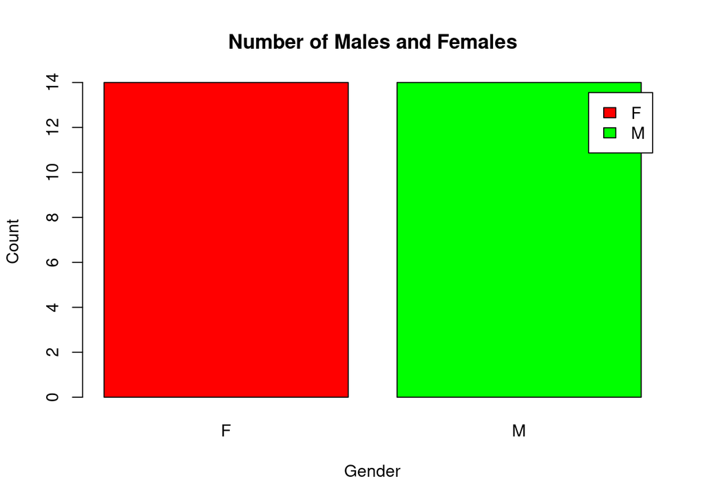

```r
totalMaleFemale <- table(accessData$Gender)
barplot(totalMaleFemale,
        main = "Number of Males and Females",
        xlab = "Gender",
        ylab = "Count",
        col = c("red", "green"),
        legend.text = rownames(totalMaleFemale),
        beside = TRUE)
```

5. The monthly income of Dela Cruz family was spent on the following: Food Electricity Savings Miscellaneous 60 | 10 | 5 | 25 5a. a. Create a piechart that will include labels in percentage.Add some colors and title of the chart. Write the R scripts and show its output.

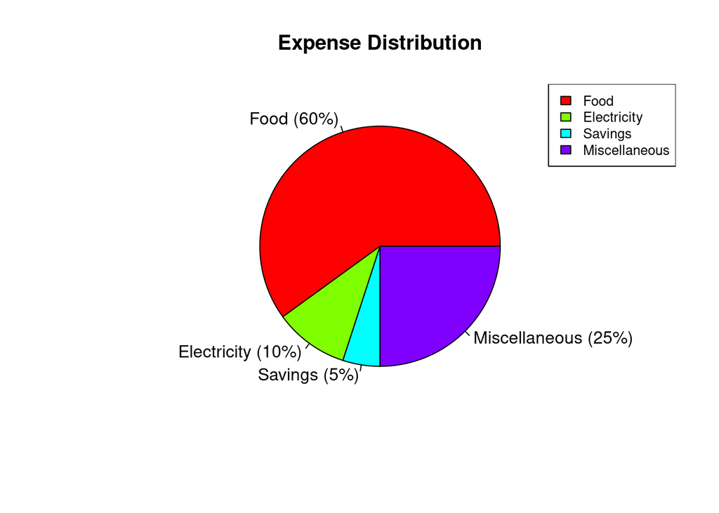

```r
# Define the data
data <- c(Food = 60, Electricity = 10, Savings = 5, Miscellaneous = 25)

# Calculate percentages and format them as strings
percentages <- paste(round(100 * data / sum(data), 1), "%", sep = "")

# Create a pie chart
pie(data, labels = paste(names(data), " (", percentages, ")", sep = ""), col = rainbow(length(data)), main = "Expense Distribution")

# Add a legend
legend("topright", names(data), cex = 0.8, fill = rainbow(length(data)))
```

6. Use the iris dataset

```r
data(iris)
```

6a. Check for the structure of the dataset using the str() function. Describe what you have seen in the output.

```r
str(iris)
```

```
## 'data.frame':    150 obs. of  5 variables:
##  $ Sepal.Length: num  5.1 4.9 4.7 4.6 5 5.4 4.6 5 4.4 4.9 ...
##  $ Sepal.Width : num  3.5 3 3.2 3.1 3.6 3.9 3.4 3.4 2.9 3.1 ...
##  $ Petal.Length: num  1.4 1.4 1.3 1.5 1.4 1.7 1.4 1.5 1.4 1.5 ...
##  $ Petal.Width : num  0.2 0.2 0.2 0.2 0.2 0.4 0.3 0.2 0.2 0.1 ...
##  $ Species     : Factor w/ 3 levels "setosa","versicolor",..: 1 1 1 1 1 1 1 1 1 1 ...
```